# Homework3

21400022 YounhongKo

2020 5 14

# Part1: Single Variable Model for Regression

## Import Library & Read CSV File

```r
PRSA <- read.csv(file = 'PRSA_data.csv')
PRSA <- na.omit(PRSA)
prsa.train <- subset(PRSA, year <= 2013)
prsa.test <- subset(PRSA, year > 2013)
```

## 1

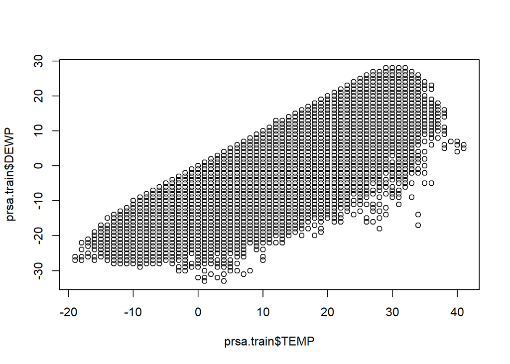

```r
plot(prsa.train$TEMP, prsa.train$DEWP)
```

> > Temperature increases in proportion to dew point

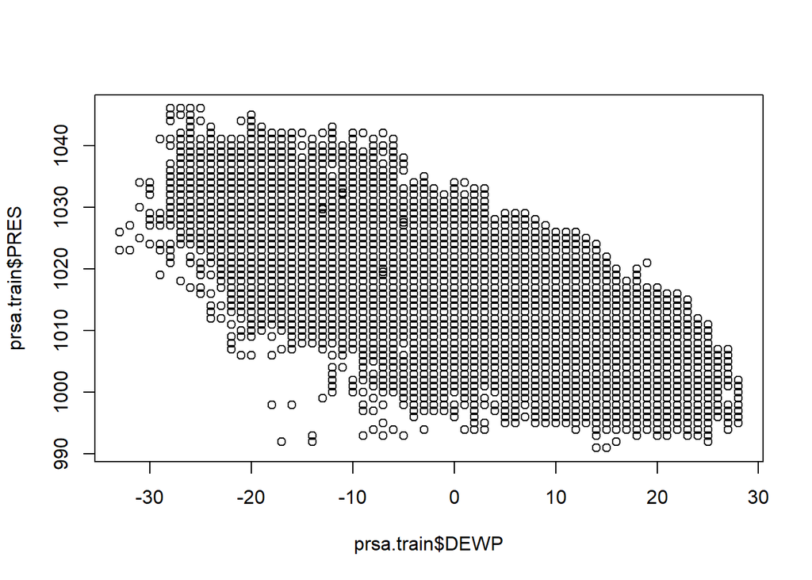

```r
plot(prsa.train$DEWP, prsa.train$PRES)
```

> > As dew point increase, pressure tends to decrease(inverse proportion)

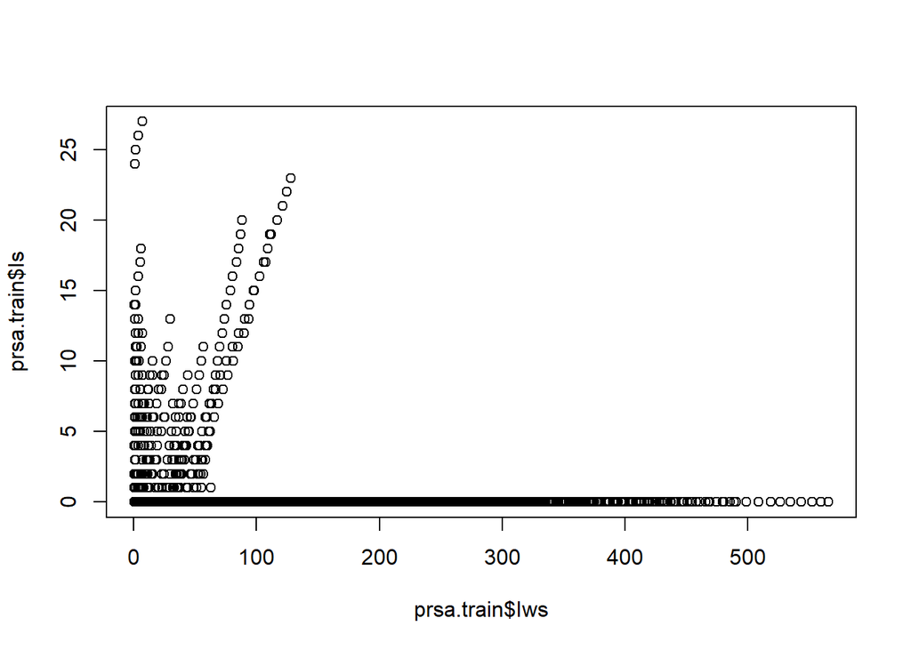

```r
plot(prsa.train$Iws, prsa.train$Is)
```

> > Cumulated hour of snow is mostly low but high value of Is is mostly from Iws lower than 150

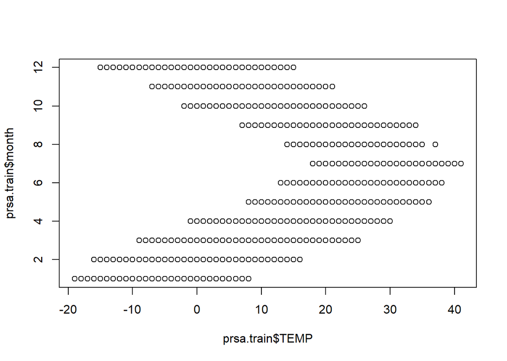

```r
plot(prsa.train$TEMP, prsa.train$month)
```

> > Temparature is max on July

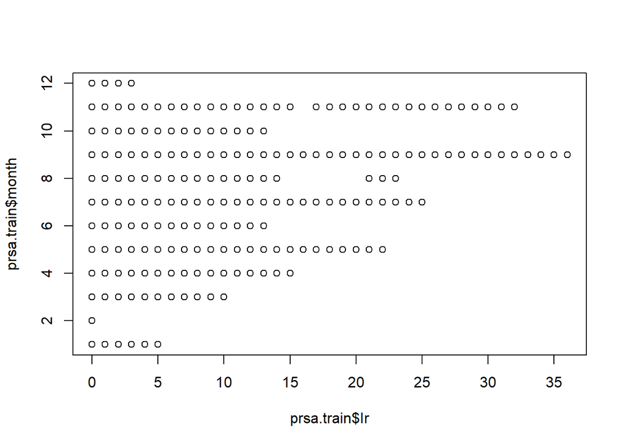

```r
plot(prsa.train$Ir, prsa.train$month)
```

> > Max cumulated hours of rain is from September.

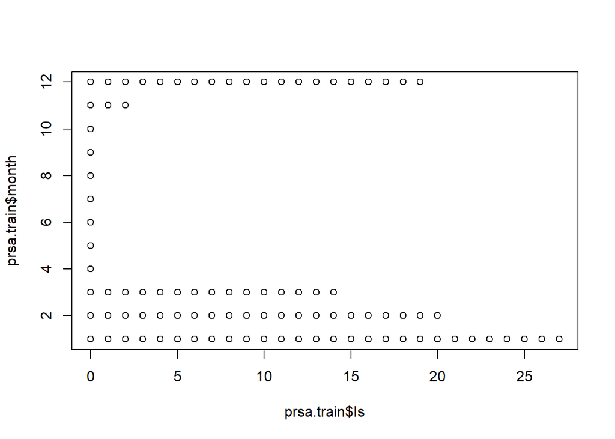

```r
plot(prsa.train$Is, prsa.train$month)
```

> > Max cumulated hour of snow is from January, followed by Februrary, December. So, it snows most in winter.

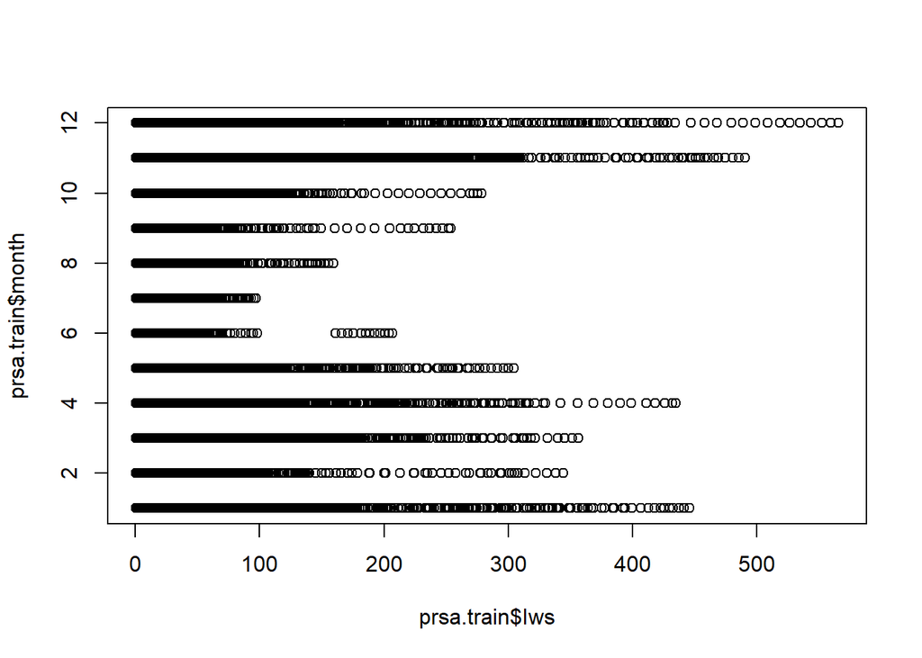

```r
plot(prsa.train$Iws, prsa.train$month)
```

> > Max cumulated speed of wind is found in December

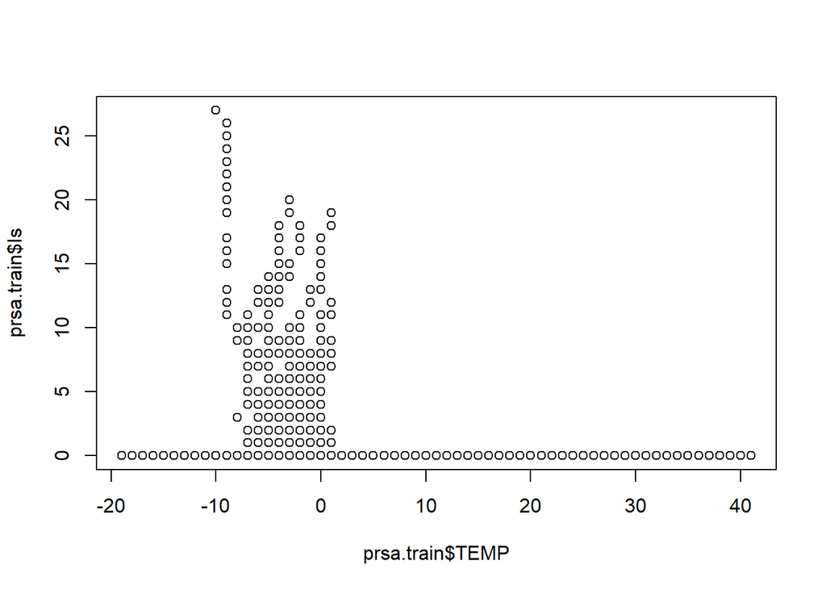

```r
plot(prsa.train$TEMP, prsa.train$Is)
```

> > High cumulated hour of snow is from temperature about -10 to 0.

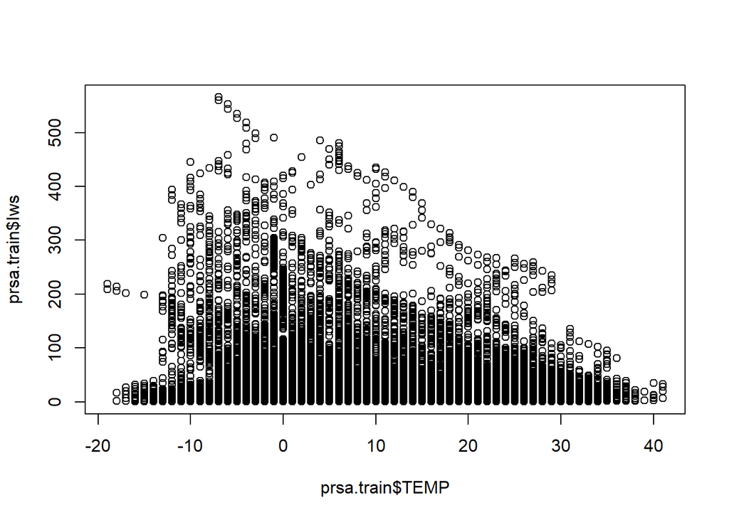

```r
plot(prsa.train$TEMP, prsa.train$Iws)
```

> > High cumulated wind speed is from tempearture between -10 and 0.

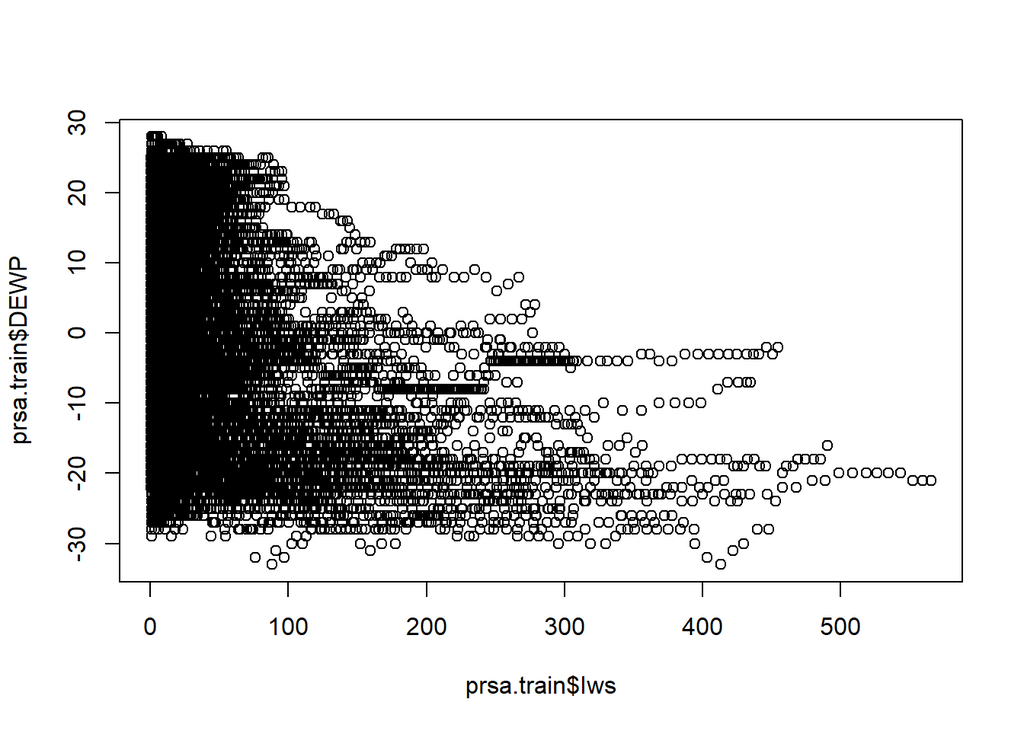

```r
plot(prsa.train$Iws, prsa.train$DEWP)
```

> > Cumulated wind speed is high from dew point about -20.

## 2

```r
sv_reg_cbwd <- tapply(prsa.train$pm2.5, prsa.train$cbwd, mean)
prsa.train$pred_pm <- sv_reg_cbwd[prsa.train$cbwd]
prsa.train$error <- prsa.train$pm2.5 - prsa.train$pred_pm
sqrt(mean(prsa.train$error ** 2))
```

```
## [1] 88.67758
```

```r
summary(prsa.train$DEWP)
```

```
##    Min. 1st Qu.  Median    Mean 3rd Qu.    Max.
## -33.000 -11.000   1.000   1.666  15.000  28.000
```

```r
prsa.train$dewp_group <- cut(prsa.train$DEWP, breaks = c(-40, -20, 0, 20, 40),
                             labels = c('-40 ~ -20', '-20 ~ 0', '0 ~ 20', '20 ~ 40'),
                             right = F)
sv_reg_dewp <- tapply(prsa.train$pm2.5, prsa.train$dewp_group, mean)
prsa.train$pred_pm <- sv_reg_dewp[prsa.train$dewp_group]
prsa.train$error <- prsa.train$pm2.5 - prsa.train$pred_pm
sqrt(mean(prsa.train$error ** 2))
```

```
## [1] 89.61707
```

```r
summary(prsa.train$TEMP)
```

```
##    Min. 1st Qu.  Median    Mean 3rd Qu.    Max.
##  -19.00    1.00   13.00   12.06   23.00   41.00
```

```r
prsa.train$temp_group <- cut(prsa.train$TEMP, breaks = c(-20, 0, 20, 40, 60),
                             labels = c('-20 ~ 0', '0 ~ 20', '20 ~ 40', '40 ~ 60'),
                             right = F)
sv_reg_temp <- tapply(prsa.train$pm2.5, prsa.train$temp_group, mean)
prsa.train$pred_pm <- sv_reg_temp[prsa.train$temp_group]
prsa.train$error <- prsa.train$pm2.5 - prsa.train$pred_pm
sqrt(mean(prsa.train$error ** 2))
```

```
## [1] 91.47395
```

```r
summary(prsa.train$PRES)
```

```
##    Min. 1st Qu.  Median    Mean 3rd Qu.    Max.
##     991    1008    1016    1016    1025    1046
```

```r
prsa.train$pres_group <- cut(prsa.train$PRES, breaks = c(990, 1010, 1030, 1050),
                             labels = c('1', '2', '3'),
                             right = F)
sv_reg_pres <- tapply(prsa.train$pm2.5, prsa.train$pres_group, mean)
prsa.train$pred_pm <- sv_reg_pres[prsa.train$pres_group]
prsa.train$error <- prsa.train$pm2.5 - prsa.train$pred_pm
sqrt(mean((prsa.train$error ** 2)))
```

```
## [1] 90.70284
```

```r
summary(prsa.train$Is)
```

```
##     Min.  1st Qu.   Median     Mean  3rd Qu.     Max.
##  0.00000  0.00000  0.00000  0.06085  0.00000 27.00000
```

```r
prsa.train$is <- as.numeric(prsa.train$Is)
prsa.train$is_group <- cut(prsa.train$is, breaks = c(0, 10.0, 20.0, 30.0),
                             labels = c('1', '2', '3'),
                             right = F)

sv_reg_is <- tapply(prsa.train$pm2.5, prsa.train$is_group, mean)
prsa.train$pred_pm <- sv_reg_pres[prsa.train$is_group]
prsa.train$error <- prsa.train$pm2.5 - prsa.train$pred_pm
sqrt(mean((prsa.train$error ** 2)))
```

```
## [1] 91.6545
```

```r
summary(prsa.train$Iws)
```

```
##    Min. 1st Qu.  Median    Mean 3rd Qu.    Max.
##    0.45    1.79    5.81   25.02   23.26  565.49
```

```r
prsa.train$iws_group <- cut(prsa.train$Iws, breaks = c(0, 100, 200, 300, 400, 500, 600),
                            labels = c('1', '2', '3', '4', '5', '5'),
                            right = F)
sv_reg_iws <- tapply(prsa.train$pm2.5, prsa.train$iws_group, mean)
prsa.train$pred_pm <- sv_reg_iws[prsa.train$iws_group]
prsa.train$error <- prsa.train$pm2.5 - prsa.train$pred_pm
sqrt(mean(prsa.train$error ** 2))
```

```
## [1] 89.64903
```

```r
summary(prsa.train$Ir)
```

```
##    Min. 1st Qu.  Median    Mean 3rd Qu.    Max.
##  0.0000  0.0000  0.0000  0.2112  0.0000 36.0000
```

```r
prsa.train$ir_group <- cut(prsa.train$Ir, breaks = c(0, 10, 20, 30, 40),
                            labels = c('1', '2', '3', '4'),
                            right = F)
sv_reg_ir <- tapply(prsa.train$pm2.5, prsa.train$ir_group, mean)
prsa.train$pred_pm <- sv_reg_ir[prsa.train$ir_group]
prsa.train$error <- prsa.train$pm2.5 - prsa.train$pred_pm
sqrt(mean(prsa.train$error ** 2))
```

```
## [1] 91.54941
```

> > Chose combined wind direction as best single variable model, since it has lowest RMSE result.

## 3

```r
sv_reg_cbwd <- tapply(prsa.train$pm2.5, prsa.train$cbwd, mean)
prsa.train$pred_pm <- sv_reg_cbwd[prsa.train$cbwd]
prsa.train$error <- prsa.train$pm2.5 - prsa.train$pred_pm
MSE_train <- mean(prsa.train$error ** 2)
RMSE_train <- sqrt(MSE_train)
RMSE_train
```

```
## [1] 88.67758
```

```r
RSS <- sum(prsa.train$error ** 2)
SStot <- sum((prsa.train$pm2.5 - mean(prsa.train$pm2.5)) ** 2)
Rsq <- 1 - RSS/SStot
print(Rsq)
```

```
## [1] 0.06396572
```

## 4

```r
prsa.test$pred_pm <- sv_reg_cbwd[prsa.test$cbwd]
prsa.test$error <- prsa.test$pm2.5 - prsa.test$pred_pm
MSE_test <- mean(prsa.test$error ** 2)
RMSE_test <- sqrt(MSE_test)
RMSE_test
```

```
## [1] 92.07007
```

```r
RSS <- sum(prsa.test$error ** 2)
SStot = sum((prsa.test$pm2.5 - mean(prsa.test$pm2.5)) ** 2)
Rsq = 1 - RSS/SStot
Rsq
```

```
## [1] 0.03089454
```

> > In test data RSME is 92.07, Rsq is 0.03

## 5

> > This model is not overfitting. Reason is that train model prediction has slightly lower result than from test model.

## 6

> > Checked with 21500802 홍영준, and our result seemed to have not big difference.

## 7

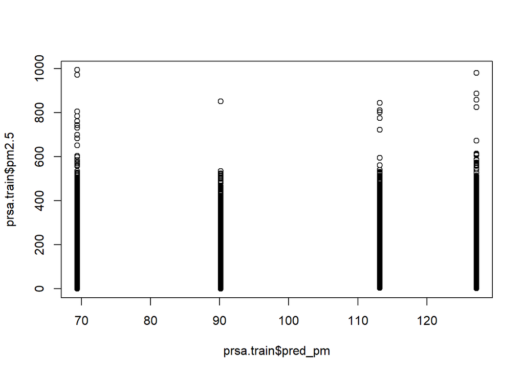

```r
plot(y=prsa.train$pm2.5, x=prsa.train$pred_pm)
```

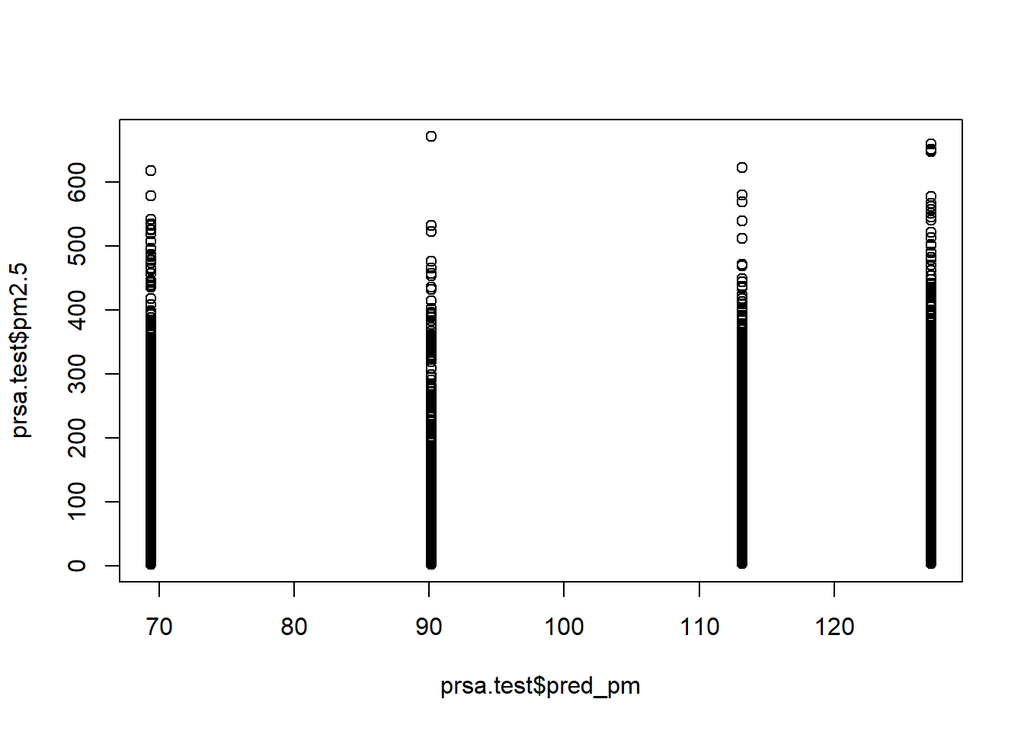

```r
plot(y=prsa.test$pm2.5, x=prsa.test$pred_pm)
```

> > With scatter plot, we can find that train data is quite accurate to predict test data since those two graphs don’t make much difference.

# Part2: Single Variable Model for Classification

## Import Library & Read RData File & Declare Function

```r
load(file = "bankruptcy.RData")
library(ROCR)
calAUC <- function(predCol, targetCol){
  perf <- performance(prediction(predCol, targetCol), 'auc')
  as.numeric(perf@y.values)
}
```

## 1

```r
tble <- table(bankruptcy_train$`Industrial Risk`, bankruptcy_train$Class)
sv_model_ir <- prop.table(tble, margin = 1)[,2]
bankruptcy_train$est_prob <- sv_model_ir[bankruptcy_train$`Industrial Risk`]
bankruptcy_test$est_prob <- sv_model_ir[bankruptcy_test$`Industrial Risk`]
calAUC(bankruptcy_train$est_prob, bankruptcy_train$Class)
```

```
## [1] 0.6352959
```

```r
tble <- table(bankruptcy_train$`Management Risk`, bankruptcy_train$Class)
sv_model_mr <- prop.table(tble, margin = 1)[,2]
bankruptcy_train$est_prob <- sv_model_mr[bankruptcy_train$`Management Risk`]
bankruptcy_test$est_prob <- sv_model_mr[bankruptcy_test$`Management Risk`]
calAUC(bankruptcy_train$est_prob, bankruptcy_train$Class)
```

```
## [1] 0.7049098
```

```r
tble <- table(bankruptcy_train$`Financial Flexibility`, bankruptcy_train$Class)
sv_model_ff <- prop.table(tble, margin = 1)[,2]
bankruptcy_train$est_prob <- sv_model_ff[bankruptcy_train$`Financial Flexibility`]
bankruptcy_test$est_prob <- sv_model_ff[bankruptcy_test$`Financial Flexibility`]
calAUC(bankruptcy_train$est_prob, bankruptcy_train$Class)
```

```
## [1] 0.900242
```

```r
tble <- table(bankruptcy_train$Credibility, bankruptcy_train$Class)
sv_model_cr <- prop.table(tble, margin = 1)[,2]
bankruptcy_train$est_prob <- sv_model_cr[bankruptcy_train$Credibility]
bankruptcy_test$est_prob <- sv_model_cr[bankruptcy_test$Credibility]
calAUC(bankruptcy_train$est_prob, bankruptcy_train$Class)
```

```
## [1] 0.9202036
```

```r
tble <- table(bankruptcy_train$Competitiveness, bankruptcy_train$Class)
sv_model_co <- prop.table(tble, margin = 1)[,2]
bankruptcy_train$est_prob <- sv_model_co[bankruptcy_train$Competitiveness]
bankruptcy_test$est_prob <- sv_model_co[bankruptcy_test$Competitiveness]
calAUC(bankruptcy_train$est_prob, bankruptcy_train$Class)
```

```
## [1] 0.9923379
```

```r
tble <- table(bankruptcy_train$`Operating Risk`, bankruptcy_train$Class)
sv_model_or <- prop.table(tble, margin = 1)[,2]
bankruptcy_train$est_prob <- sv_model_or[bankruptcy_train$`Operating Risk`]
bankruptcy_test$est_prob <- sv_model_or[bankruptcy_test$`Operating Risk`]
calAUC(bankruptcy_train$est_prob, bankruptcy_train$Class)
```

```
## [1] 0.6523843
```

> > Chose competitiveness as best single variable model since it has maximum AUC. Its AUC for train data is about 0.9923.

## 2

```r
calAUC(bankruptcy_test$est_prob, bankruptcy_test$Class)
```

```
## [1] 1
```

> > AUC for test data is 1.

## 3

> > This model is not overfitting. Reason is that train model prediction has slightly lower result than from test model.

## 4

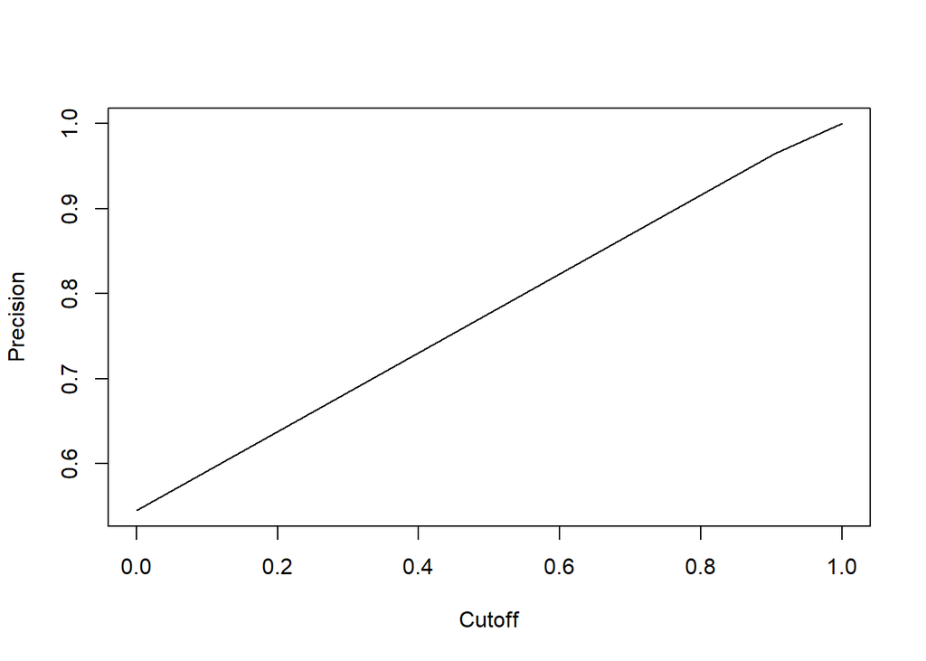

```r
plot(performance(prediction(bankruptcy_train$est_prob,
                            bankruptcy_train$Class),'prec', 'cutoff'))
```

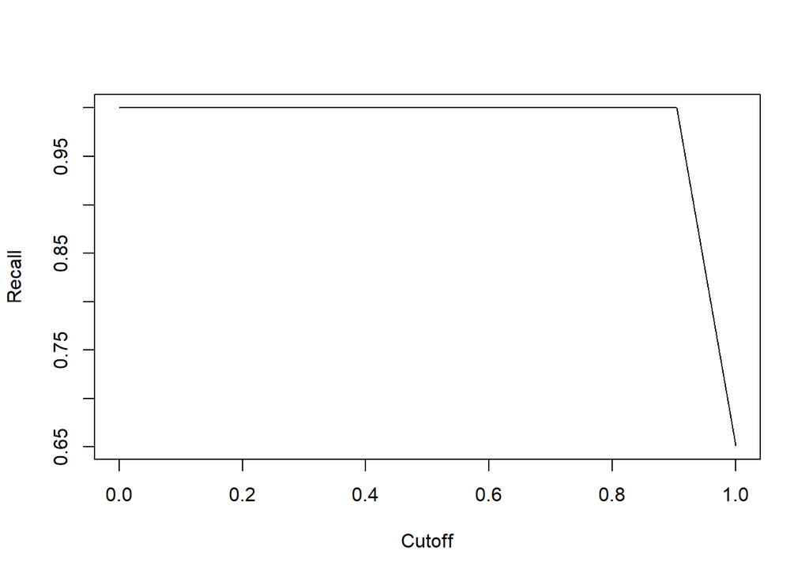

```r
plot(performance(prediction(bankruptcy_train$est_prob,
                            bankruptcy_train$Class),'rec', 'cutoff'))
```

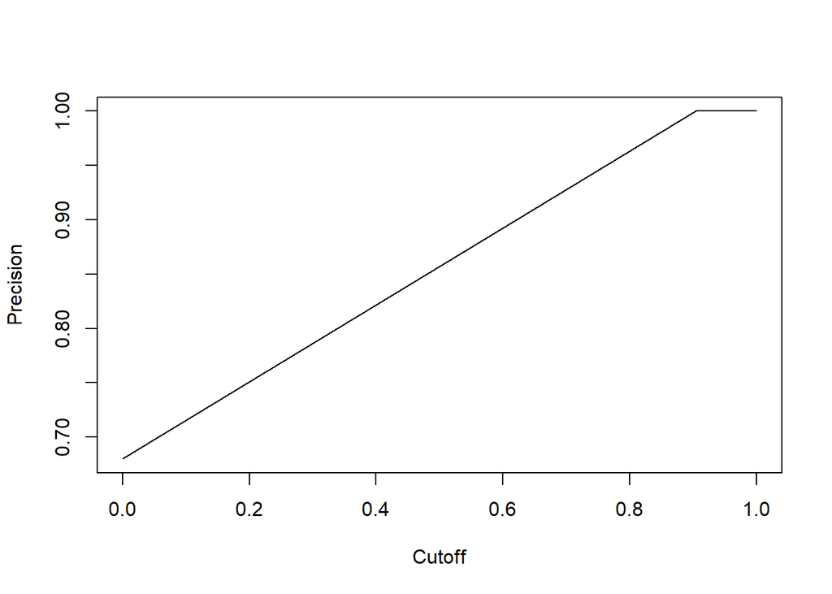

```r
plot(performance(prediction(bankruptcy_test$est_prob,
                            bankruptcy_test$Class),'prec', 'cutoff'))
```

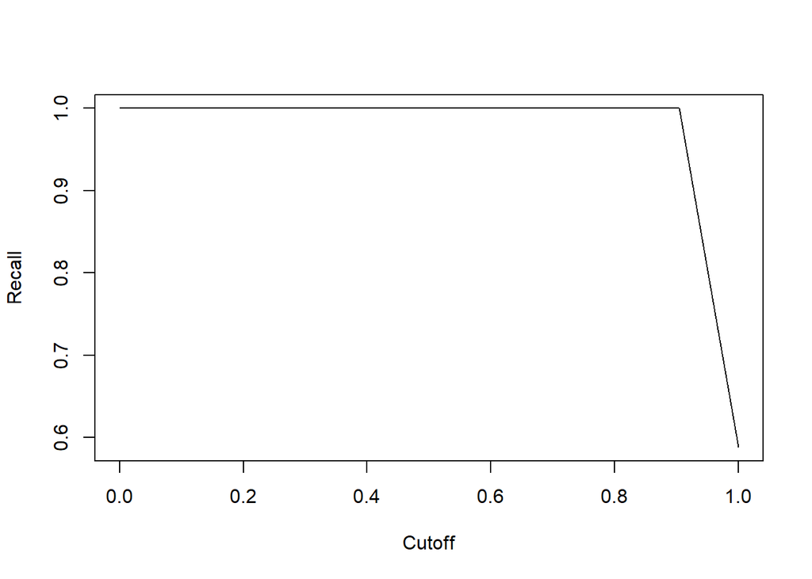

```r
plot(performance(prediction(bankruptcy_test$est_prob,
                            bankruptcy_test$Class),'rec', 'cutoff'))
```

```r
performance(prediction(bankruptcy_train$est_prob,
                            bankruptcy_train$Class),'rec', 'cutoff')@x.values
```

```
## [[1]]
## [1]       Inf 1.0000000 0.9047619 0.0000000
```

```r
performance(prediction(bankruptcy_test$est_prob,
                            bankruptcy_test$Class),'rec', 'cutoff')@x.values
```

```
## [[1]]
## [1]       Inf 1.0000000 0.9047619 0.0000000
```

> > Precision increase as threshold increase, and threshold is max when threshold is lower than 0.91.  
> > On this model, recall is more important, it is good to choose recall is max which is about 0.9

## 5

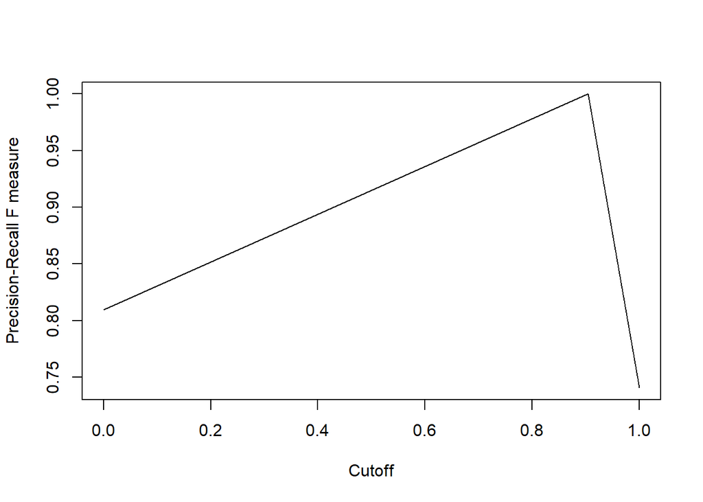

```r
plot(performance(prediction(bankruptcy_test$est_prob,
          bankruptcy_test$Class),'f', 'cutoff'))
```

```r
performance(prediction(bankruptcy_test$est_prob,
          bankruptcy_test$Class),'f', 'cutoff')@x.values
```

```
## [[1]]
## [1]       Inf 1.0000000 0.9047619 0.0000000
```

> > From graph, F1 is max on about 0.904

## 6

```r
?performance
```

```
## starting httpd help server ... done
```

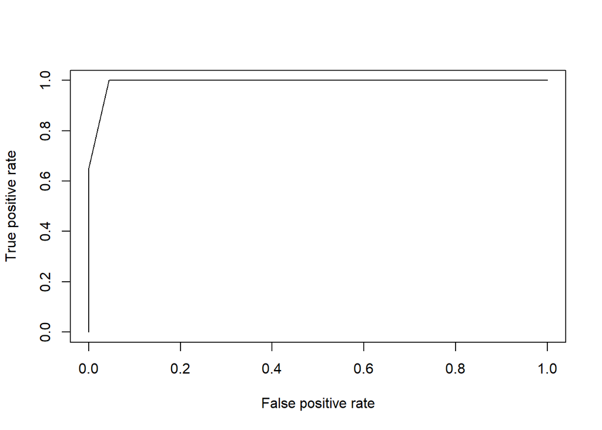

```r
plot(performance(prediction(bankruptcy_train$est_prob,
           bankruptcy_train$Class),'tpr', 'fpr'))
```

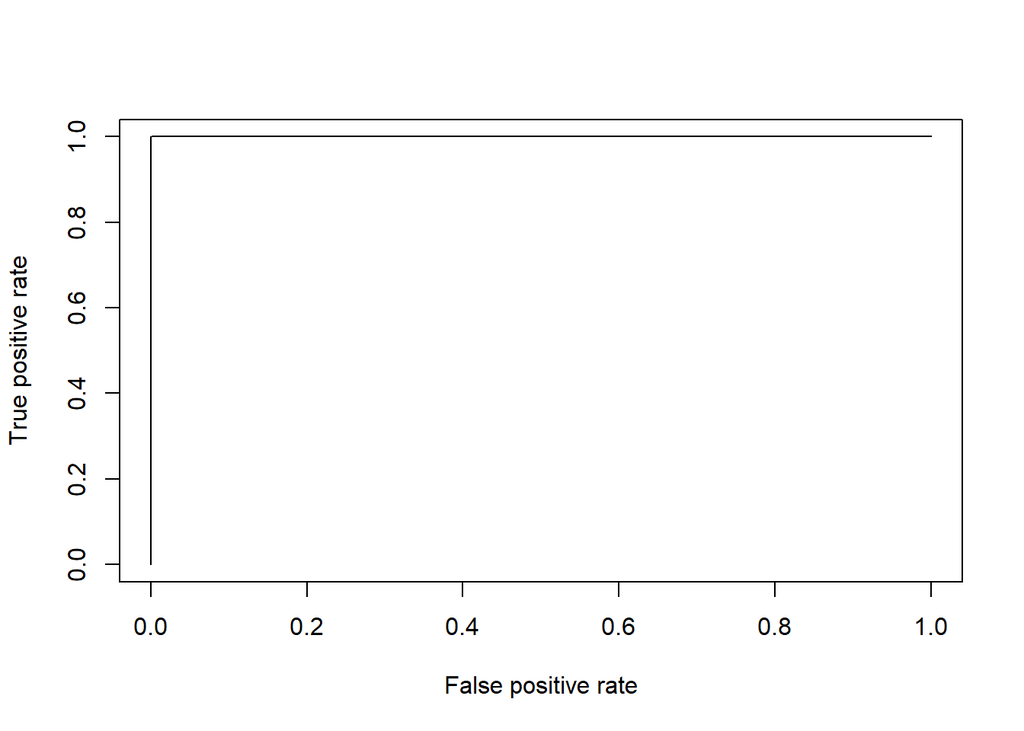

```r
plot(performance(prediction(bankruptcy_test$est_prob,
           bankruptcy_test$Class),'tpr', 'fpr'))
```

## 7

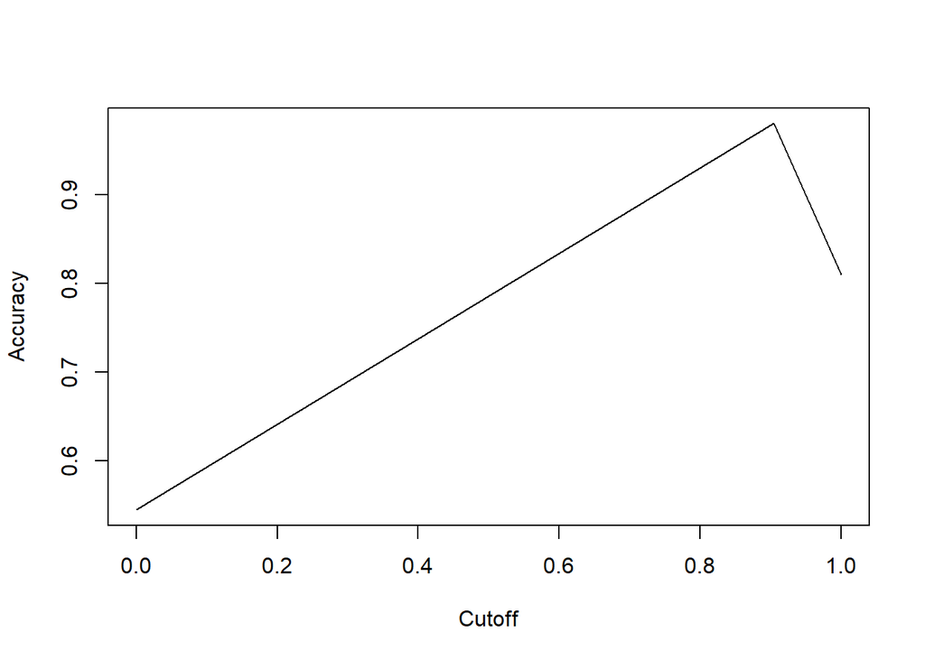

```r
plot(performance(prediction(bankruptcy_train$est_prob,
           bankruptcy_train$Class),'acc', 'cutoff'))
```

```r
performance(prediction(bankruptcy_train$est_prob,
           bankruptcy_train$Class),'acc', 'cutoff')@x.values
```

```
## [[1]]
## [1]       Inf 1.0000000 0.9047619 0.0000000
```

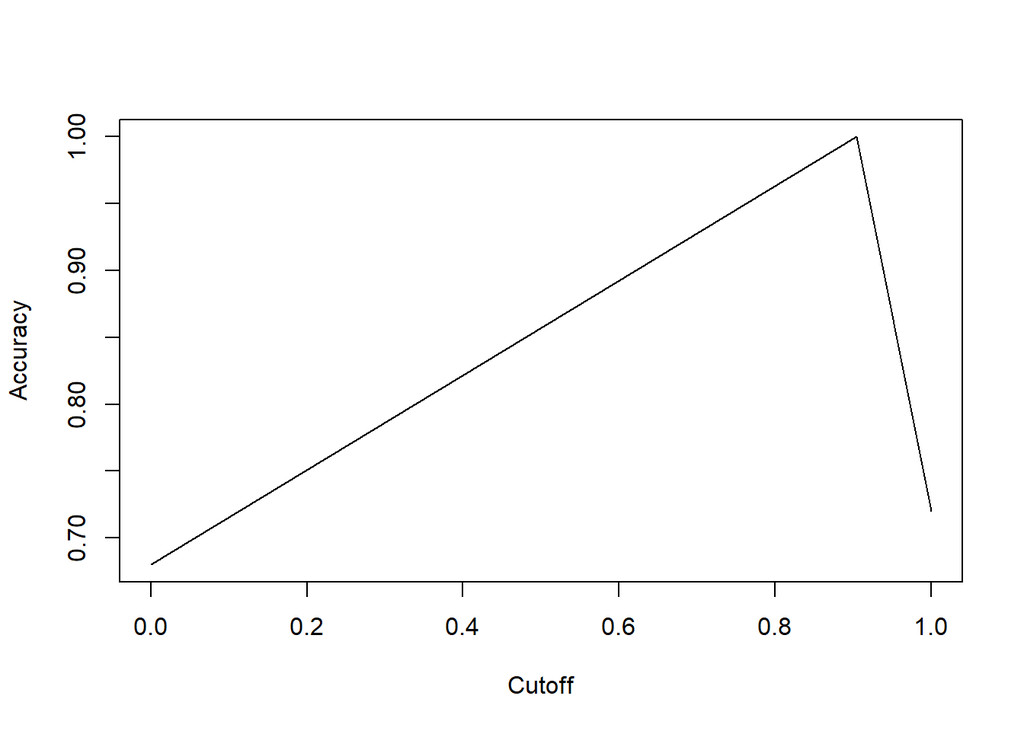

```r
plot(performance(prediction(bankruptcy_test$est_prob,
           bankruptcy_test$Class),'acc', 'cutoff'))
```

```r
performance(prediction(bankruptcy_test$est_prob,
           bankruptcy_test$Class),'acc', 'cutoff')@x.values
```

```
## [[1]]
## [1]       Inf 1.0000000 0.9047619 0.0000000
```

> > Threshold is max when threshold is about 0.904

## 8

> > Checked with 21500802 홍영준, and our result seemed to have not big difference.